# Introduction to sensometrics and R

Block 1 · exercises 1 – 4

Sensometrics in R · SaIT

## What is sensometrics?

- **Sensory analysis** measures food properties with the human senses.
- **Sensometrics** is the statistics for these measurements: how to design an experiment, analyse it and what to trust in the results.

The measuring instrument is a **human being**: gets tired, adapts, everyone uses the scale differently. That is why we need statistics, not just means.

## The path of a sensory experiment

**Question**  
does the new recipe differ?→**Design**  
test, panel, order→**Evaluation**  
sheets, apps→**Data**  
data.frame in R→**Analysis**  
test, model, plot→**Decision**  
change / keep

In this course we go through all the steps – from design through analysis to interpretation.

## R and RStudio

**R** – the language and computing engine

**RStudio** – the editor around it:

1. script editor
2. console
3. variables (Environment)
4. plots and help

```r
install.packages("sensR")  # once
library(sensR)             # every time
?binom.test                # help
```

Write code in a **script**, not in the console – otherwise you cannot repeat the analysis.

## Data structures

```r
vector <- c(7.5, 6.9, 7.0, 7.2)            # one dimension, one type
m <- matrix(1:6, nrow = 2)                 # filled by columns
tab <- data.frame(
  assessor = c("H1", "H2", "H3"),
  product = c("A", "A", "B"),
  taste = c(7, 6, 8)
)
tab$taste                                  # column via $
```

```
[1] 7 6 8
```

```r
mean(tab$taste)
```

```
[1] 7
```

## Designing an experiment in R

```r
plan <- expand.grid(assessor = paste0("H", 1:4), product = c("A", "B", "C"))
set.seed(24)
plan$order <- ave(seq_len(nrow(plan)), plan$assessor, FUN = function(x) sample(length(x)))
head(plan[order(plan$assessor, plan$order), ], 6)
```

```
   assessor product order
5        H1       B     1
9        H1       C     2
1        H1       A     3
10       H2       C     1
6        H2       B     2
2        H2       A     3
```

Every assessor gets every product in a random serving order – this suppresses order and fatigue effects.

## QUIZ `each` or `times`?

What does `rep(c("A", "B"), each = 2)` return?

1. `"A" "B" "A" "B"`
2. `"A" "A" "B" "B"`

**2.** `each` repeats every element, `times` the whole vector. Together they create a complete assessor × product plan.

## Modified BCG matrix

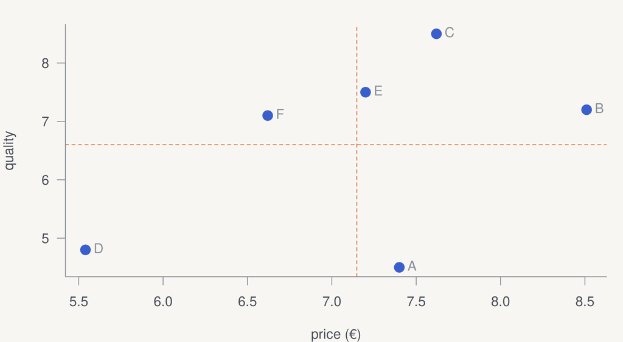

```r
price <- c(7.40, 8.51, 7.62, 5.54, 7.20, 6.62)
quality <- c(4.5, 7.2, 8.5, 4.8, 7.5, 7.1)
plot(price, quality, pch = 19, col = pal[3],
     cex = 1.6, xlab = "price (€)",
     ylab = "quality")
abline(v = mean(price), h = mean(quality),
       col = pal[2], lty = 2)
text(price, quality, LETTERS[1:6], pos = 4)
```

Quadrants by the means: top left **good value** (F), bottom right **problem** (A – expensive and the worst).

## Confidence interval of the mean

The panel mean is only an **estimate**. A confidence interval shows its uncertainty:

$$\bar{x} \pm t_{0.975;\,n-1} \cdot \frac{s}{\sqrt{n}}$$

```r
x <- c(10, 9, 11, 10, 10, 9, 10)                      # 7 assessors
delta <- sd(x) / sqrt(length(x)) * qt(0.975, df = length(x) - 1)
round(c(lower = mean(x) - delta, mean = mean(x), upper = mean(x) + delta), 2)
```

```
lower  mean upper
 9.22  9.86 10.50
```

The denominator uses the **number of ratings** `length(x)`, not the number of distinct values `length(unique(x))`.

## Why t and not 1.96?

```r
n <- c(5, 7, 10, 20, 30, 100)
round(data.frame(n = n, t = qt(0.975, df = n - 1)), 2) |> t()
```

```
  [,1] [,2]  [,3]  [,4]  [,5]   [,6]
n 5.00 7.00 10.00 20.00 30.00 100.00
t 2.78 2.45  2.26  2.09  2.05   1.98
```

With a small panel we only have an estimate of the variance → the t-distribution has heavier tails and the interval is wider. With 7 assessors t = 2.45, not 1.96.

## Which chart when?

| Question | Chart in R |
| --- | --- |
| Which product has the highest rating? | `barplot()`, `dotchart()` |
| Do products also differ in spread? | `boxplot()` |
| What is the distribution of values? | `hist()`, `plot(density())` |
| How does a value change over time? | `plot(type = "l")` + `lines()` |
| Are two variables related? | `plot(x, y)` |

## Box plot: five numbers in one chart

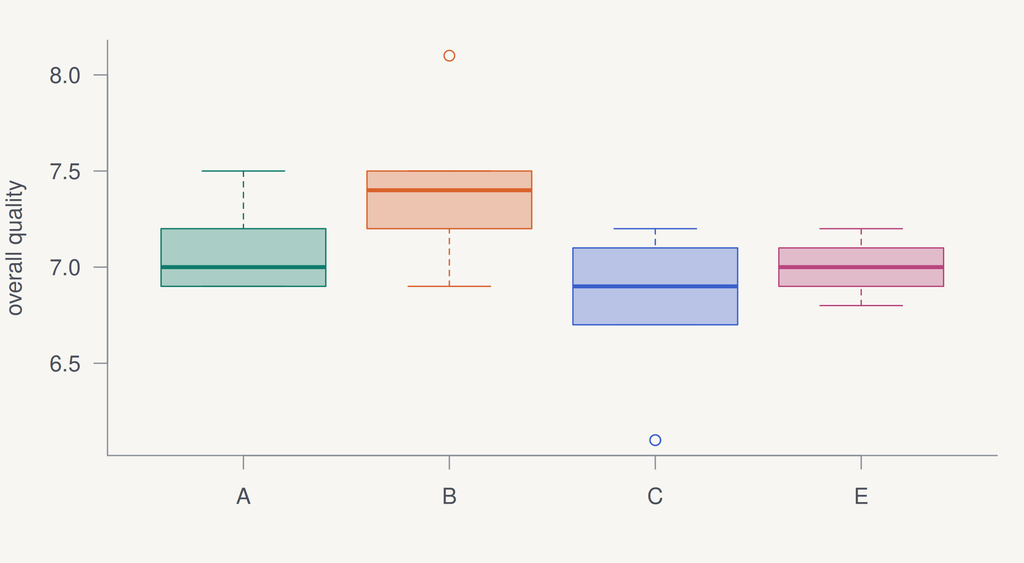

```r
cheeses <- data.frame(
  A = c(7.5, 6.9, 7, 7, 6.9, 7.1, 7.2, 7.5, 6.9),
  B = c(7.5, 8.1, 7.5, 7.4, 7.1, 7.5, 7.2, 7.2, 6.9),
  C = c(7, 6.1, 6.7, 6.1, 6.9, 7.1, 7.2, 7.2, 6.9),
  E = c(6.8, 6.9, 6.9, 7, 7, 7, 7.1, 7.1, 7.2)
)
boxplot(cheeses, col = paste0(pal[1:4], "55"),
        border = pal[1:4],
        ylab = "overall quality")
```

Thick line = median, box = middle 50% of the data, points beyond the whiskers = outliers.

## Charts in layers

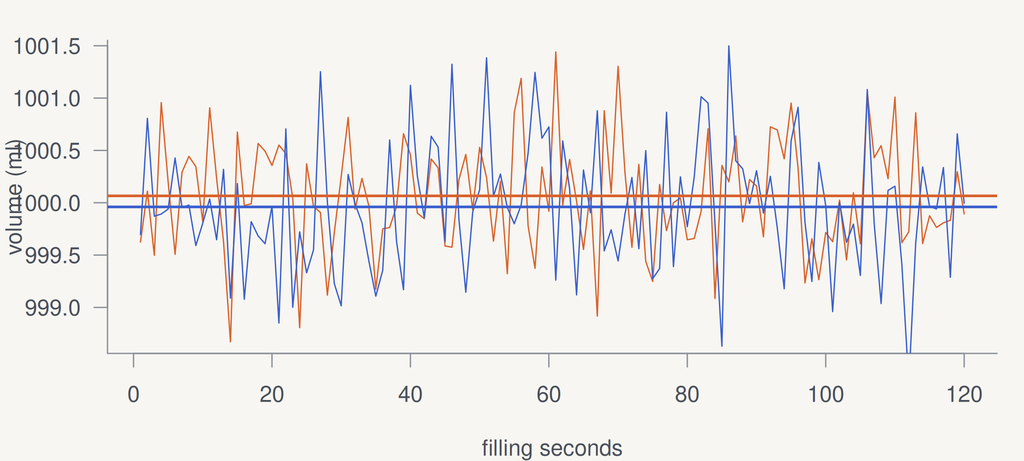

```r
set.seed(1)
line1 <- rnorm(120, mean = 1000, sd = 0.6)
line2 <- rnorm(120, mean = 1000, sd = 0.6)
plot(line1, type = "l", col = pal[2], xlab = "filling seconds", ylab = "volume (ml)")
lines(line2, col = pal[3])
abline(h = c(mean(line1), mean(line2)), col = pal[2:3], lwd = 2)
```

## QUIZ Choose a chart

You want to show management that the **new recipe has a smaller spread** of ratings than the old one. Which chart?

**Box plot** – it shows the median and the spread (box height) of both recipes side by side. A bar chart of means would hide the spread.

## Summary

- Sensory data = a human measuring instrument → **variability** is part of the measurement.
- In R we work with **scripts** and data in a **data.frame** (one row = one rating).
- Always report a mean with a **confidence interval**, with the t-distribution for small panels.
- First the **plot**, then the test.

Theory 1 Theory 2 Theory 3 Theory 4 [Scripts](https://github.com/senzorika/SaIT)